# Making Box Plots for AACR Poster

Jaron Magstadt

August 2024

## Notebook Tasks

The things I did in this notebook are:

- Read in NTA data from canine exosome samples
- Filtered data to only include relevant conditions/results
- Generated summary statistics using the `summarize` function
- Created box plots displaying data of interest
- Made the box plots look **pretty!**

## Setup Steps

To setup, I started by loading in the packages I needed.

```r
library(tidyverse)
```

I continued setup by setting my working directory and paths.

```r
#I assigned the path to my working directory to a variable and then set my wd.
main_dir <- file.path("~","Documents","repos","ALSF_Training")
setwd(main_dir)

#I assigned the path for my data directory to a variable.
data_dir <- file.path(main_dir, "data")

#I set up a directory for my plots to go to
plots_dir <- file.path(main_dir,"plots")
fs::dir_create(plots_dir)
```

## Reading in Data

```r
NTA_data <- read_csv(file.path(data_dir, "NTA_concentrations_cleaner.csv"))
```

It worked! **YAY!**

## Viewing Data

Like Stephanie says, **always** look at your data! My data frame isn’t terribly large, but still unwieldy, so I will use the `head()`, `summary()`, and `names()` functions to look at my data.

```r
head(NTA_data)
```

| Code | Dog_name | Last_name | Group | Sex | Weight | BCS | Breed | Height | Age | Size | Size_SD | Concentration | Notes | Date of NTA | ...16 |
| --- | --- | --- | --- | --- | --- | --- | --- | --- | --- | --- | --- | --- | --- | --- | --- |
| COED1-001 | Watson | Desalvo | HC | MN | 30.00 | 5 | Labrador retriever | 23 | 4.33 | 86.2 | 40.8 | 2.85e+11 | NA | 6/2/23 | NA |
| COED1-002 | Rebel | Mattson | HC | MN | 23.00 | 5 | Mix | 22 | 4.09 | 115.0 | 39.8 | 2.75e+11 | skin allergies (cytopoint) | 6/21/23 | NA |
| COED1-003 | Pepper | Ueda | HC | FS | 10.00 | 4 | English cocker spaniel | 17 | 2.02 | 118.2 | 26.6 | 7.22e+10 | NA | 6/23/23 | NA |
| COED1-004 | Valley | Potter | HC | FS | 33.00 | 4 | German Shepherd | 26 | 2.39 | 111.7 | 61.8 | 9.87e+10 | NA | 6/21/23 | NA |
| COED1-005 | Juno | Sanford | HC | FI | 40.82 | 5 | Borzoi | 29 | 3.34 | 91.1 | 40.5 | 8.48e+11 | NA | 6/23/23 | NA |
| COED1-007 | Stegasaurus | Waldsmith | HC | FS | 35.00 | 6 | Great dane | 30 | 3.42 | 75.1 | 36.0 | 4.68e+11 | NA | 7/17/23 | NA |

```r
summary(NTA_data)
```

```
     Code             Dog_name          Last_name
 Length:55          Length:55          Length:55
 Class :character   Class :character   Class :character
 Mode  :character   Mode  :character   Mode  :character




    Group               Sex                Weight           BCS
 Length:55          Length:55          Min.   : 3.72   Min.   :3.000
 Class :character   Class :character   1st Qu.:21.45   1st Qu.:5.000
 Mode  :character   Mode  :character   Median :30.00   Median :5.000
                                       Mean   :29.30   Mean   :5.598
                                       3rd Qu.:36.00   3rd Qu.:6.000
                                       Max.   :62.00   Max.   :8.000
                                                       NA's   :4
    Breed               Height           Age              Size
 Length:55          Min.   :11.00   Min.   : 1.170   Min.   : 60.4
 Class :character   1st Qu.:17.00   1st Qu.: 3.155   1st Qu.: 83.8
 Mode  :character   Median :20.00   Median : 4.870   Median :107.6
                    Mean   :19.86   Mean   : 6.449   Mean   :102.5
                    3rd Qu.:22.25   3rd Qu.: 9.670   3rd Qu.:119.5
                    Max.   :30.00   Max.   :12.750   Max.   :141.6
                    NA's   :27
    Size_SD      Concentration          Notes
 Min.   :21.80   Min.   :2.410e+10   Length:55
 1st Qu.:35.20   1st Qu.:3.015e+11   Class :character
 Median :41.80   Median :6.110e+11   Mode  :character
 Mean   :43.44   Mean   :9.219e+11
 3rd Qu.:52.45   3rd Qu.:1.155e+12
 Max.   :67.40   Max.   :4.380e+12

 Date of NTA           ...16
 Length:55          Length:55
 Class :character   Class :character
 Mode  :character   Mode  :character
```

```r
names(NTA_data)
```

```
 [1] "Code"          "Dog_name"      "Last_name"     "Group"
 [5] "Sex"           "Weight"        "BCS"           "Breed"
 [9] "Height"        "Age"           "Size"          "Size_SD"
[13] "Concentration" "Notes"         "Date of NTA"   "...16"
```

That’s a lot of information! But we don’t need all of the information in the data frame to do the analyses that I am interested in, so lets do some filtering.

## Filtering and Summarizing Data

There are many types of cancer/controls in the data frame I read into R. I am only interested in `"OSA"` and `"HC"`, so I created a character vector that contained these labels to help with an upcoming step.

```r
my_groups <- c("OSA","HC")
my_groups
```

```
[1] "OSA" "HC"
```

Now that I had a vector containing the names of the conditions I’m interest in, I was able to create a pipeline to create a summary of the average size and concentration of exosomes in the `"OSA"` and `"HC"` conditions. I used the `filter()` function along with the `mygroups` vector to only keep the conditions I was interested in, then used the `summarize` function to make a table of summary statistics.

```r
NTA_summary <- NTA_data |>
  filter(Group %in% my_groups) |>
  group_by(Group) |>
  summarize(Mean_Size = mean(Size),
            Std_Dev_Size = sd(Size),
            Mean_Concentration = mean(Concentration),
            Std_Dev_Concentration = sd(Concentration)
  )
 NTA_summary
```

| Group | Mean_Size | Std_Dev_Size | Mean_Concentration | Std_Dev_Concentration |
| --- | --- | --- | --- | --- |
| HC | 107.0769 | 18.13199 | 4.996500e+11 | 2.721624e+11 |
| OSA | 83.9250 | 18.98742 | 1.137625e+12 | 1.417971e+12 |

Look at that! I can now see the mean size and concentration, as well as standard deviations, for the `"HC"` and `"OSA"` conditions!

## Making Data Frames to Use With ggplot2

Now it was time time move onto the main objective: **making pretty plots for a poster.**

Well…**almost**…

In order to make plots, I wanted to have more concise data frames that only had the data I was interested in. This wasn’t entirely necessary, but I wanted to make sure the data was pulling into the plot correctly, and doing things this way ensured that, at least in my mind. I did this by using the `filter()` function again in a set of two pipelines: one for exosome size and one for exosome concentration.

```r
 #Making size table for plot
 NTA_size <- NTA_data |>
   filter(Group %in% my_groups) |>
   group_by(Group) |>
   select(Size)
 NTA_size
```

| Group | Size |
| --- | --- |
| HC | 86.2 |
| HC | 115.0 |
| HC | 118.2 |
| HC | 111.7 |
| HC | 91.1 |
| HC | 75.1 |
| HC | 125.1 |
| HC | 117.5 |
| HC | 79.4 |
| OSA | 60.4 |

[output cut: 24 more lines]

```r
 #Making concentration table for plot
 NTA_conc <- NTA_data |>
   filter(Group %in% my_groups) |>
   group_by(Group) |>
   select(Concentration)
NTA_conc
```

| Group | Concentration |
| --- | --- |
| HC | 2.85e+11 |
| HC | 2.75e+11 |
| HC | 7.22e+10 |
| HC | 9.87e+10 |
| HC | 8.48e+11 |
| HC | 4.68e+11 |
| HC | 5.50e+11 |
| HC | 6.82e+11 |
| HC | 2.05e+11 |
| OSA | 7.21e+11 |

[output cut: 24 more lines]

## Making Box Plots using ggplot2

Finally, the time came: it was time to **make my box plots!!** To do this, I used `ggplot` to create a plot for my NTA size data. I used `geom_boxplot` to add the data to the plot and set the line width. I then used many arguments to make the plots pretty, which can be seen in the code below (examples include `theme(bw)`, `theme()`, and `scale_fill_manual`).

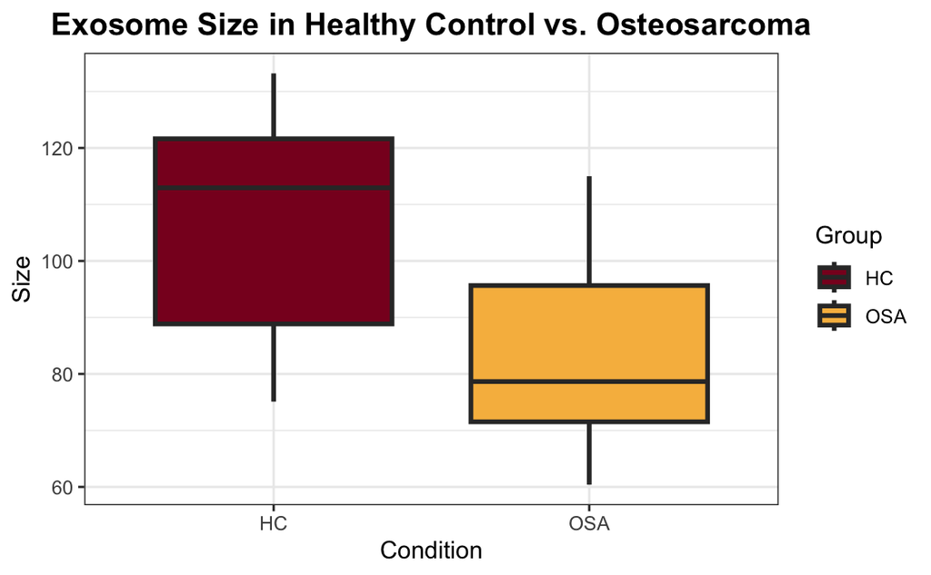

```r
#Graphing Size
 NTA_size_bp <- ggplot(
   NTA_size,
   aes(
     x = Group,
     y = Size,
     fill = Group,
     )
 )+ geom_boxplot(lwd = 1, fatten=1) +
   theme_bw() +
   theme(plot.title = element_text(size = 14, face = "bold", hjust=0.5)) +
   scale_fill_manual(values=c("#8a0a25", "#f7ba4d")) +
   labs(
     x = "Condition",
     y = "Size",
     title = "Exosome Size in Healthy Control vs. Osteosarcoma"
   )

 NTA_size_bp
```

And then I did the same thing, but for the `NTA_conc` data frame to create a plot displaying exosome concentration between conditions.

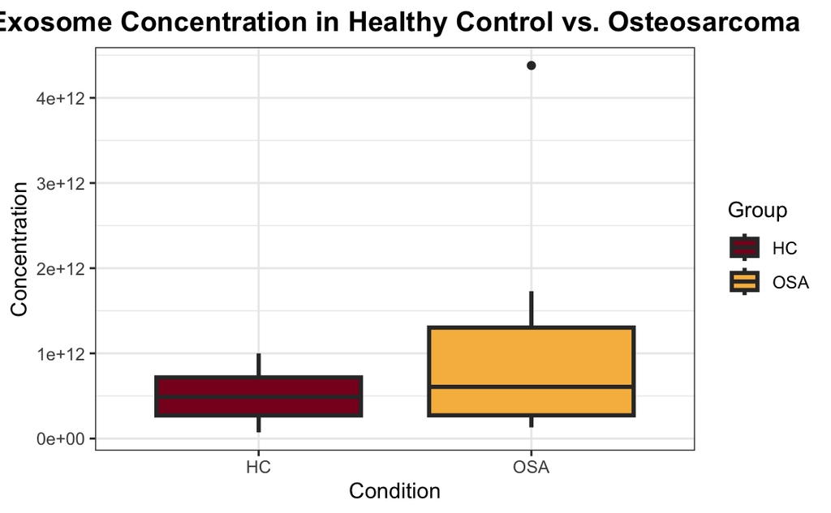

```r
 #Graphing Concentration
 NTA_conc_bp <- ggplot(
   NTA_conc,
   aes(
     x = Group,
     y = Concentration,
     fill = Group
   )
 )+ geom_boxplot(lwd = 1, fatten=1) +
   theme_bw() +
   theme(plot.title = element_text(size = 14, face = "bold", hjust=0.5)) +
   scale_fill_manual(values=c("#8a0a25", "#f7ba4d")) +
   labs(
     x = "Condition",
     y = "Concentration",
     title = "Exosome Concentration in Healthy Control vs. Osteosarcoma"
   )

NTA_conc_bp
```

There is an outlier that makes this box plot a little funny, but that outlier is important to the data, so I decided to keep it.

## Saving the Box Plots

As my very last step, I saved my plots. I used `ggsave` to do this. Within the function, I set the file name within the directory for plots I made at the beginning and set the size I wanted for the plots.

```r
 ggsave( #Saving size plot
   plot = NTA_size_bp,
   filename = file.path(plots_dir,"NTA_size_bp.png"),
   width = 6,
   height = 6
 )

 ggsave( #Saving concentration plot
   plot = NTA_conc_bp,
   filename = file.path(plots_dir,"NTA_conc_bp.png"),
   width = 6,
   height = 6
 )
```

## Conclusion

Thank you for taking the time to read through my process of creating box plots from exosome NTA data. I hope you enjoyed it!